# Spatial Data Analysis in Python and R

## Example Dataset: NYC traffic accidents, localized to US Census blocks

The dataset we’re using is that used in the analysis published in 2019 [Bayesian Hierarchical Spatial Models: Implementing the Besag York Mollié Model in Stan](https://www.sciencedirect.com/science/article/pii/S1877584518301175).

The data consists of motor vehicle collisions in New York City, as recorded by the NYC Department of Transportation, between the years 2005-2014, restricted to collisions involving school age children 5-18 years of age as pedestrians.

Each crash was localized to the US Census tract in which it occurred, using boundaries from the 2010 United States Census, using the [2010 Census block map for New York City](https://data.cityofnewyork.us/City-Government/2010-Census-Blocks/v2h8-6mxf) The US Census tract is the lowest level of Census data resolution. A tract contains between 2,500 and 8,000 residents and boundaries that follow visible features. According to the [Census Bureau](https://www2.census.gov/geo/pdfs/reference/GARM/Ch10GARM.pdf)

> When first established, census tracts are to be as homogeneous as possible with respect to population characteristics, economic status, and living condition

### Measures

> We obtained motor vehicle collision data from the New York City Department of Transportation for the ten most recent years of data available at the time of request (2005-2014). Within this dataset, we identified collisions involving school age children 5-18 years of age as pedestrians. We then assigned each crash to the census tract in which it occurred, using boundaries from the 2010 United States Census.

> We obtained 2010 US Census counts of youths aged 5-18 in each census tract from the US Census Bureau [@us-census] We also obtained the Census Bureau’s American Community Survey (ACS) five-year estimates of median household income and the percentage of commuters who traveled to work by means other than a private vehicle (i.e., by walking, bicycling, or using public transportation) for each tract for 2010-2014. We constructed an index of social fragmentation based on the work of Peter Congdon, using updated ACS estimates of vacant housing units, householders living alone, non-owner occupied housing units, and population having moved within the previous year. We standardized each of these metrics with a mean of zero and added them together as a single index. Finally, we obtained street level annual average daily traffic (AADT) data from the New York State Department of Transportation on the New York Open Data portal. We created a spatial overlay of streets and census tracts to assign each census tract the maximum AADT value of its underlying streets in 2015.

| Measures | Median | Min | Mean | Max |
| --- | --- | --- | --- | --- |
| Youth pedestrian injuries, 2005-14 | 6 | 0 | 8.2 | 57 |
| Population ages 5-18 years, 2010 | 510 | 6 | 596.4 | 3,315 |
| Med. household income in USD, 2010-14 | $53,890 | $9,327 | $58,497 | $232,266 |
| Pct. commute by walk/cycle/public trans, 2010-14 | 73.9 | 9.7 | 69.8 | 100.0 |
| Standardized social fragmentation index | -0.1 | -6.7 | 0.0 | 18.7 |
| Traffic Volume (AADT), 2015 | 19,178 | 843 | 37,248 | 276,476 |

## Spatial Data manipulation in R and Python

Geographic information systems (GIS) data is any item which has a geographic location, either a single point or a set of bounding polygons. Cartographic data (maps) are encoded as a set of records, one per map region. The [shapefile format](https://en.wikipedia.org/wiki/Shapefile) is an open specification used to insure interoperability among GIS software packages. When items in a dataset contain location labels, it is necessary to obtain a set of shapefiles for the corresponding map. To compute with GIS data, we need packages which can do the geographic math.

- [GeoPandas](https://geopandas.org/en/stable/) extends the datatypes used by pandas to allow spatial operations on geometric types, which are equivalent to the operations provided by R’s [`sf`](https://r-spatial.github.io/sf/) package.
- [`libpysal`](https://pysal.org/libpysal/) is spatial analysis package which can analyze distance between locations; operations equivalent to R’s [`spdep`](https://r-spatial.github.io/spdep/) package.

To visualize GIS data, we need to be able to draw maps and spatial graphs.

- In R, ggplot2 can produce beautiful maps for GIS data.
- The python equivalent of R’s `ggplot2` is [`plotnine`](https://plotnine.org/).
- The [`splot`](https://pysal.org/notebooks/viz/splot/intro.html) provides additional plotting functions for spatial graph networks.

## Preliminary Data Analysis

### Notebook Startup: Load Packages / Libraries

```r
library(sf)
library(spdep) |> suppressPackageStartupMessages()
library(ggplot2)
library(tidyverse) |> suppressPackageStartupMessages()
```

### Load study data

The study data and GIS data have been assembled into a single GeoJSON file.

```r
nyc_geodata = st_read(file.path("data", "nyc_study.geojson"))
class(nyc_geodata)
```

```
[1] "sf"         "data.frame"
```

```r
names(nyc_geodata)
```

```
 [1] "CTLabel"        "BoroCode"       "BoroName"       "CT2010"
 [5] "BoroCT2010"     "CDEligibil"     "NTACode"        "NTAName"
 [9] "PUMA"           "Shape_Leng"     "Shape_Area"     "BoroFips"
[13] "ct2010full"     "kids_per_sq_mi" "count"          "kid_pop"
[17] "pct_pubtransit" "med_hh_inc"     "traffic"        "frag_index"
[21] "geometry"
```

```r
table(nyc_geodata$BoroName)
```

```
        Bronx      Brooklyn     Manhattan        Queens Staten Island
          329           745           274           639           108
```

#### Traffic accidents - kids hit by cars

Plot the observed outcome `counts`.

*Note:* Count data is properly plotted as a bar chart, not histogram plus density, but the visualization is useful.

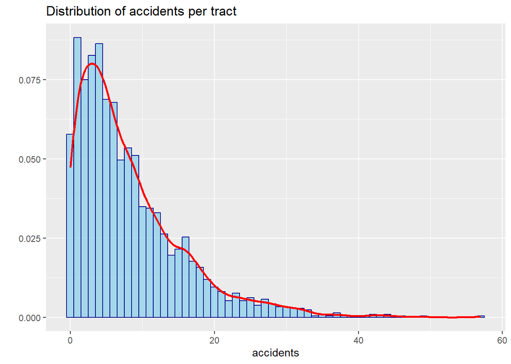

```r
ggplot(data = nyc_geodata, aes(x = count)) +
  geom_histogram(aes(y = after_stat(density)), bins = 58, color = 'DarkBlue', fill = "skyblue", alpha = 0.7) +
  geom_density(color = "red", linewidth = 1) +
  ggtitle("Distribution of accidents per tract") +
  xlab("accidents") +
  ylab("")
```

### Visualize by Map Areas

#### Show areal map, fill color is accidents per tract

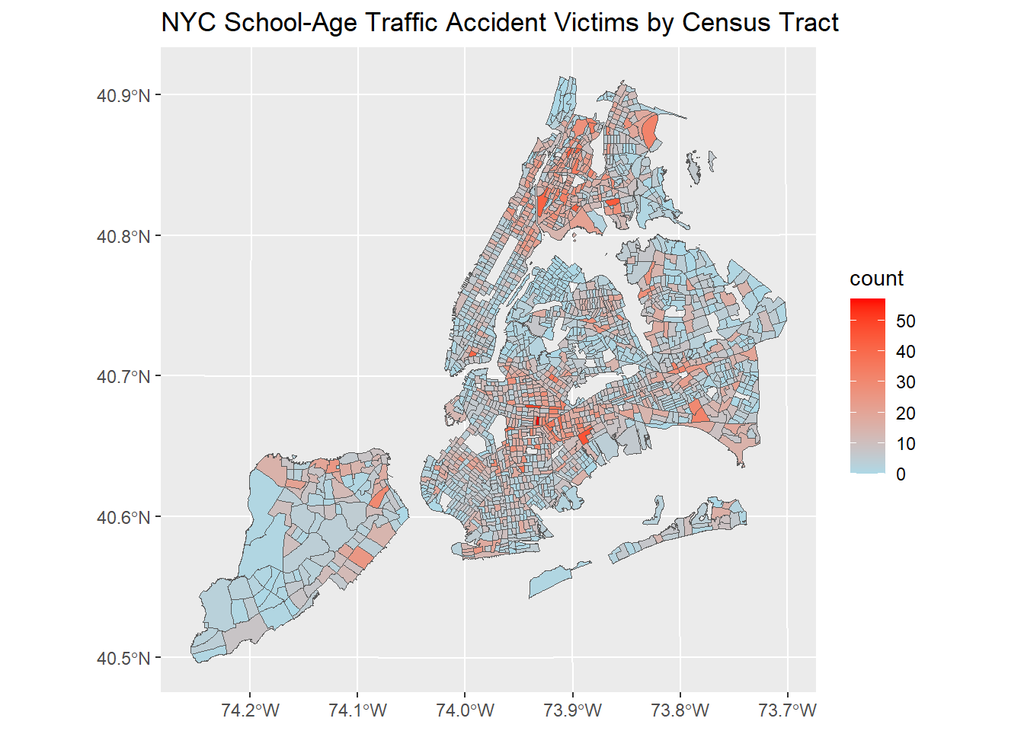

```r
ggplot(data = nyc_geodata) +
geom_sf(aes(fill = count)) +
scale_fill_gradient(low = "lightblue", high = "red") +
labs(title = "NYC School-Age Traffic Accident Victims by Census Tract")
```

#### Show areal map, fill color is kid population per tract

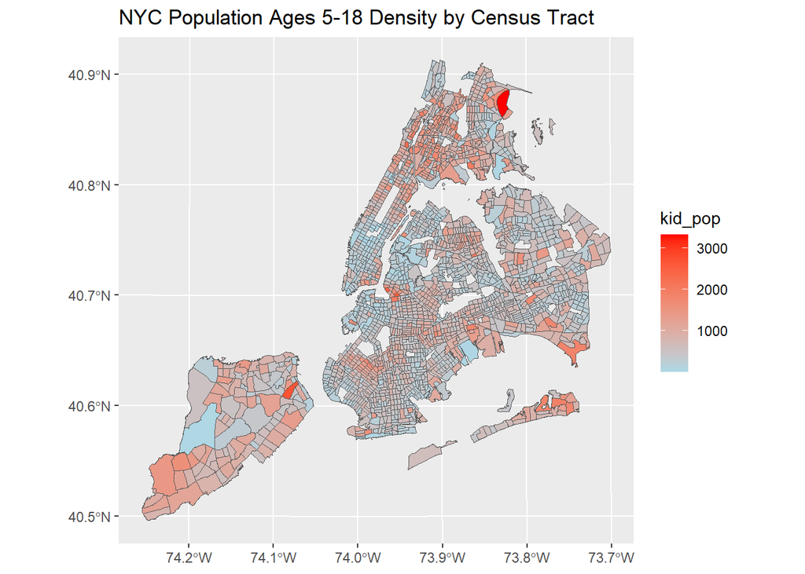

```r
ggplot(data = nyc_geodata) +
    geom_sf(aes(fill = kid_pop)) +
    scale_fill_gradient(low = "lightblue", high = "red") +
    labs(title = "NYC Population Ages 5-18 Density by Census Tract")
```

#### Population: raw counts, density per square mile

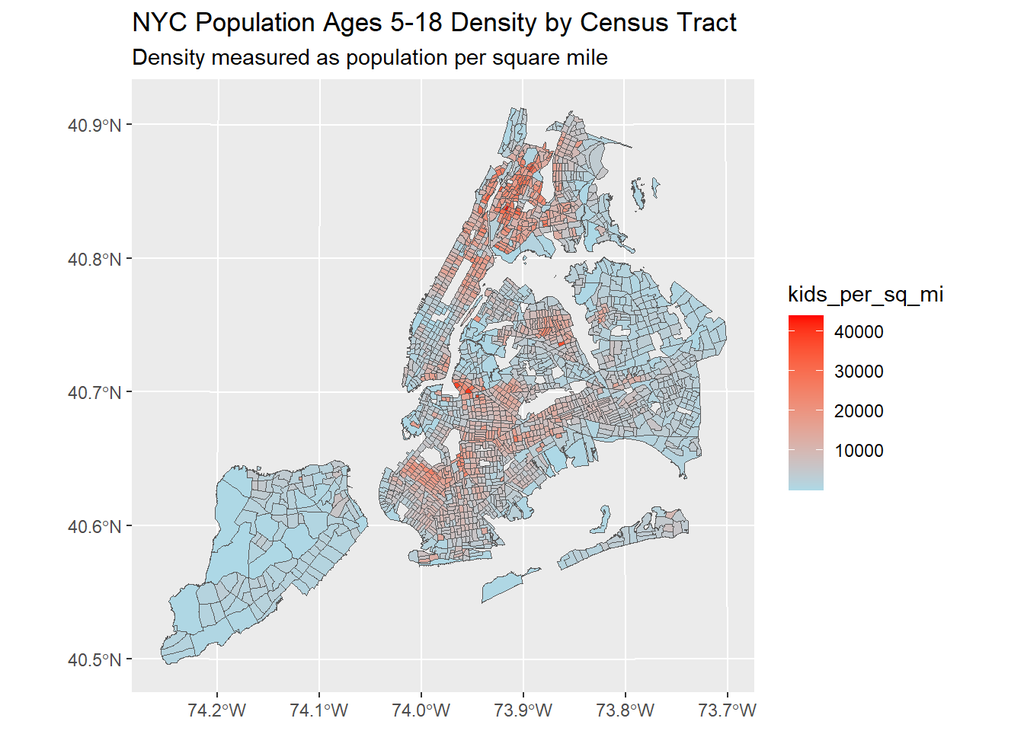

```r
ggplot(data = nyc_geodata) +
    geom_sf(aes(fill = kids_per_sq_mi)) +
    scale_fill_gradient(low = "lightblue", high = "red") +
    labs(title = "NYC Population Ages 5-18 Density by Census Tract",
         subtitle = "Density measured as population per square mile")
```

## Exercises

- Visualize `med_hh_inc` (median household income), `frag_index` (fragmentation index), and `traffic`.
- Create histograms of predictors `med_hh_inc`, `traffic`. How can these be rescaled?

## Spatial Smoothing For Areal Data: From Maps to Graphs

By defining a neighbor relationship between area regions, we convert a map to a graph.

- The *neighbor relation* is defined in terms of shared areal boundaries
- Neighborhood networks are computed from `nyc_geodata` spatial geometry component
  - Python package `libpysal`
  - R package `spdep`

We need to compute the adjacency network between the regions in our map.

In Python, use [`libpysal`](https://pysal.org/libpysal/), a Python library for spatial analysis, which we have imported as `sa`. To visualize this graph overlaid on the county map, use [splot](https://splot.readthedocs.io/en/latest/), a lightweight visualization interface.

In R, use [`spdep`](https://r-spatial.github.io/spdep/) package.

There are several ways to define the neighbor relationship, see https://pysal.org/libpysal/api.html#spatial-weights. Here we use the *Rook* metric: regions which share a common line boundary are neighbors.

- Python spatial weights object: [weights.W](https://pysal.org/libpysal/generated/libpysal.weights.W.html#libpysal-weights-w)
- R spatial weights object: [`nb`](https://r-spatial.r-universe.dev/spdep/doc/manual.html#summary.nb)

```r
nyc_nbs = poly2nb(nyc_geodata, queen=FALSE)
summary(nyc_nbs)
```

```
Neighbour list object:
Number of regions: 2095
Number of nonzero links: 10332
Percentage nonzero weights: 0.2354054
Average number of links: 4.931742
3 regions with no links:
329, 1861, 1904
8 disjoint connected subgraphs
Link number distribution:

  0   1   2   3   4   5   6   7   8   9  10  11  12
  3   7  33 217 553 652 400 150  56  10   8   4   2
7 least connected regions:
214 319 1311 1312 1329 1863 1974 with 1 link
2 most connected regions:
1023 1621 with 12 links
```

As the map shows, the neighborhood network is not fully connected.

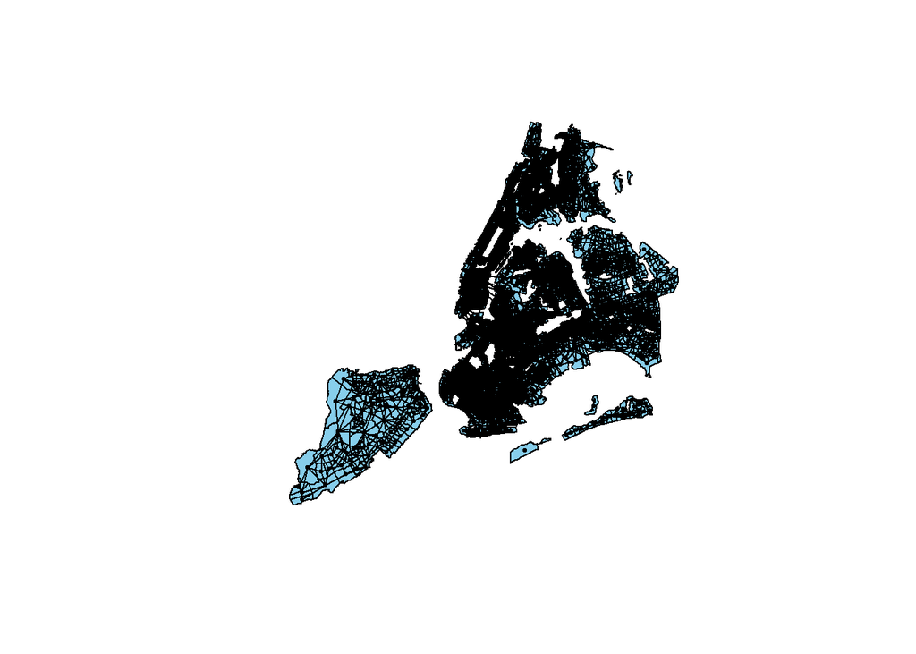

```r
nyc_coords = st_coordinates(st_centroid(nyc_geodata['geometry']))
plot(st_geometry(nyc_geodata), col='skyblue')
plot(nyc_nbs, coords=nyc_coords, add=TRUE, pch=20, cex=0.6)
```

In [A note on intrinsic Conditional Autoregressive models for disconnected graphs](https://arxiv.org/abs/1705.04854), Freni-Sterrantino et.al. show how to implement the BYM2 model for use with areal data where the graph structure of the map is not fully connected, and we can implement this strategy using Stan.

However, for the simple ICAR example, we restrict our analysis to the borough of Brooklyn.

```r
brooklyn_geodata = nyc_geodata[nyc_geodata$BoroName=='Brooklyn', ]
brooklyn_nbs = poly2nb(brooklyn_geodata, queen=FALSE)
summary(brooklyn_nbs)
```

```
Neighbour list object:
Number of regions: 745
Number of nonzero links: 3804
Percentage nonzero weights: 0.6853745
Average number of links: 5.10604
Link number distribution:

  2   3   4   5   6   7   8   9  10  12
  7  56 164 261 176  56  17   5   2   1
7 least connected regions:
390 398 842 844 876 1057 1070 with 2 links
1 most connected region:
1023 with 12 links
```

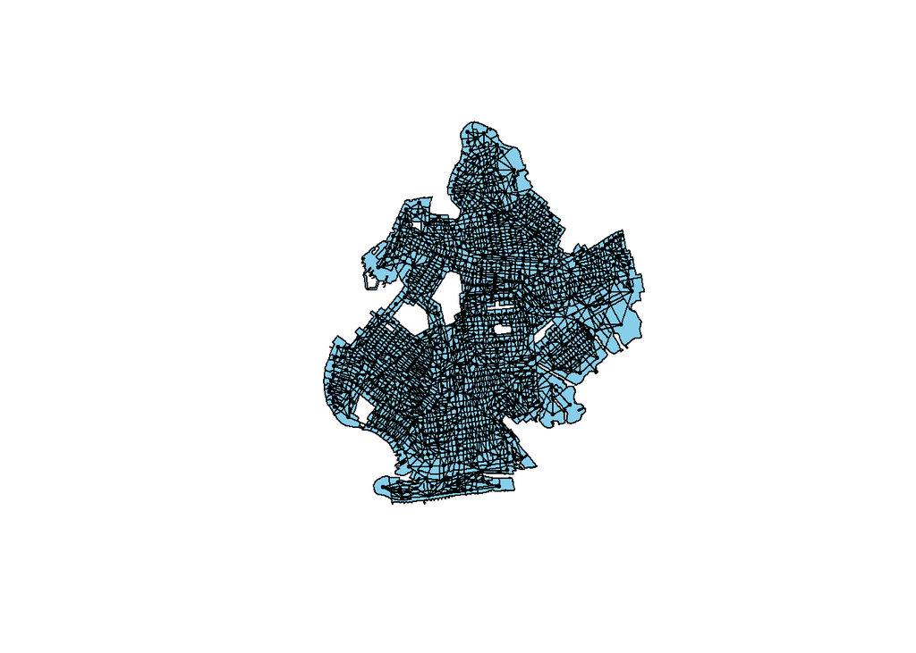

```r
brooklyn_coords = st_coordinates(st_centroid(brooklyn_geodata['geometry']))
plot(st_geometry(brooklyn_geodata), col='skyblue')
plot(brooklyn_nbs, coords=brooklyn_coords, add=TRUE, pch=20, cex=0.6)
```